# Machine Learning

Ulrich NGUEMDJO

13/07/2020

## Introduction

One thing that people regularly do is quantify how much of a particular activity they do, but they rarely quantify how well they do it. The goal of the present project is to predict the manner in which people do their exercise using data from accelerometers on the belt, forearm, arm, and dumbell of 6 participants.

## Data loading and processing

### Loading the data

We first start by loading the Url of the training data set and the testing data set.

```r
# loading libraries
library(caret)
library(rpart)
```

```r
library(rpart.plot)
library(RColorBrewer)
library(rattle)
library(randomForest)
# loading data
trainUrl <- "https://d396qusza40orc.cloudfront.net/predmachlearn/pml-training.csv"
testUrl <- "https://d396qusza40orc.cloudfront.net/predmachlearn/pml-testing.csv"
trainingRaw <- read.csv(trainUrl)
testingRaw <- read.csv(testUrl)
dim(trainingRaw); dim(testingRaw)
```

```
## [1] 19622   160
```

```
## [1]  20 160
```

```r
rm(trainUrl) # removing the training URL in th environment
rm(testUrl)  # removing the testing URL in th environment
```

### Cleaning data

Before proceeding to data splitting, we first clean our data.

1. **We remove the nearest zero variables in the data sets**

```r
NZV <- nearZeroVar(trainingRaw, saveMetrics=TRUE)
head(NZV, 15)
```

```
##                        freqRatio percentUnique zeroVar   nzv
## X                       1.000000  100.00000000   FALSE FALSE
## user_name               1.100679    0.03057792   FALSE FALSE
## raw_timestamp_part_1    1.000000    4.26562022   FALSE FALSE
## raw_timestamp_part_2    1.000000   85.53154622   FALSE FALSE
## cvtd_timestamp          1.000668    0.10192641   FALSE FALSE
## new_window             47.330049    0.01019264   FALSE  TRUE
## num_window              1.000000    4.37264295   FALSE FALSE
## roll_belt               1.101904    6.77810621   FALSE FALSE
## pitch_belt              1.036082    9.37722964   FALSE FALSE
## yaw_belt                1.058480    9.97349913   FALSE FALSE
## total_accel_belt        1.063160    0.14779329   FALSE FALSE
## kurtosis_roll_belt   1921.600000    2.02323922   FALSE  TRUE
## kurtosis_picth_belt   600.500000    1.61553358   FALSE  TRUE
## kurtosis_yaw_belt      47.330049    0.01019264   FALSE  TRUE
## skewness_roll_belt   2135.111111    2.01304658   FALSE  TRUE
```

```r
train1 <- trainingRaw[, !NZV$nzv]
test1 <- testingRaw[, !NZV$nzv]
dim(train1); dim(test1)
```

```
## [1] 19622   100
```

```
## [1]  20 100
```

```r
rm(trainingRaw) # removing the raw training set in th environment
rm(testingRaw)  # removing the raw testing set in th environment
rm(NZV)         # removing the NZV info URL in th environment
```

2. **We remove variables that do not contribute in accelerometer measurements**

```r
IDvariables <- grepl("^X|timestamp|user_name", names(train1))
training <- train1[, !IDvariables]
testing <- test1[, !IDvariables]
```

3. **We remove columns with NA**: We plot the training set to visualize variables with missing values before deleting them.

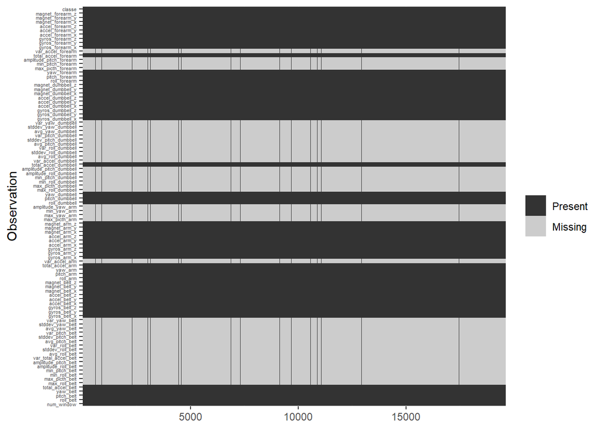

```r
training %>%
        is.na() %>%
        reshape2::melt() %>%
        ggplot(aes(Var2, Var1, fill=value)) +
        geom_raster() +
        coord_flip() +
        scale_y_continuous(NULL, expand = c(0, 0)) +
        scale_fill_grey(name = "",
                        labels = c("Present",
                                   "Missing")) +
        xlab("Observation") +
        theme(axis.text.y  = element_text(size = 4))
```

```r
# deleting variables with NA
cond <- (colSums(is.na(training)) == 0)
training <- training[, cond]
testing <- testing[, cond]
rm(cond)
```

### Data splitting

To apply the different approach we think can be use to predict the way of doing exercise, we split our training data into 2 data sets; a data set which will be use to train our models called `trainSet` (which represent 70% of the data) and a data set which will be use to test our model `testSet` (which represent 30% of the data).

We set a seed to `2020` to make our results reproducible.

```r
set.seed(2020)
intrain <- createDataPartition(y = training$classe, p = 0.70, list = FALSE)
trainSet <- training[intrain, ]
testSet <- training[-intrain, ]
dim(trainSet); dim(testSet)
```

```
## [1] 13737    54
```

```
## [1] 5885   54
```

```r
rm(intrain)
```

## Our predicting approach

We decided to use two different models to predict using this data: **Decision Trees** and **Random Forests**.

### Decision Trees

We fit our model using a decision tree

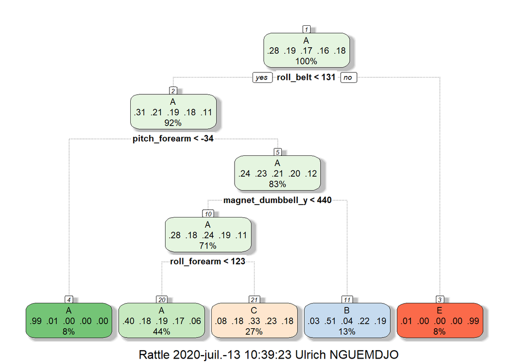

```r
modelTree <- train(classe ~ ., data = trainSet, method = "rpart")
fancyRpartPlot(modelTree$finalModel)
```

After fitting, we can now test our model on the testing set `testSet`.

```r
predictTree <- predict(modelTree, newdata = testSet)
confusionMatrix(as.factor(testSet$classe), predictTree)
```

```
## Confusion Matrix and Statistics
##
##           Reference
## Prediction    A    B    C    D    E
##          A 1529   21  123    0    1
##          B  476  378  285    0    0
##          C  463   42  521    0    0
##          D  441  173  350    0    0
##          E  144  150  292    0  496
##
## Overall Statistics
##
##                Accuracy : 0.4969
##                  95% CI : (0.484, 0.5097)
##     No Information Rate : 0.5188
##     P-Value [Acc > NIR] : 0.9996
##
##                   Kappa : 0.3425
##
##  Mcnemar's Test P-Value : NA
##
## Statistics by Class:
##
##                      Class: A Class: B Class: C Class: D Class: E
## Sensitivity            0.5008  0.49476  0.33164       NA  0.99799
## Specificity            0.9488  0.85140  0.88294   0.8362  0.89124
## Pos Pred Value         0.9134  0.33187  0.50780       NA  0.45841
## Neg Pred Value         0.6381  0.91867  0.78391       NA  0.99979
## Prevalence             0.5188  0.12982  0.26695   0.0000  0.08445
## Detection Rate         0.2598  0.06423  0.08853   0.0000  0.08428
## Detection Prevalence   0.2845  0.19354  0.17434   0.1638  0.18386
## Balanced Accuracy      0.7248  0.67308  0.60729       NA  0.94461
```

From this matrix of confusion, the accuracy rate of our Decision Tree model is **49.69%**.

### Random Forests

We fit no the data using a Random Forest model.

```r
modelRF <- train(classe ~ ., data = trainSet,method = "rf", trControl = trainControl(method = "cv", 5), ntree = 250)
modelRF
```

```
## Random Forest
##
## 13737 samples
##    53 predictor
##     5 classes: 'A', 'B', 'C', 'D', 'E'
##
## No pre-processing
## Resampling: Cross-Validated (5 fold)
## Summary of sample sizes: 10990, 10988, 10990, 10990, 10990
## Resampling results across tuning parameters:
##
##   mtry  Accuracy   Kappa
##    2    0.9926477  0.9906993
##   27    0.9965786  0.9956721
##   53    0.9935210  0.9918041
##
## Accuracy was used to select the optimal model using the largest value.
## The final value used for the model was mtry = 27.
```

After fitting, we can now test our model on the testing set `testSet`.

```r
predictRF <- predict(modelRF, testSet)
confusionMatrix(as.factor(testSet$classe), predictRF)
```

```
## Confusion Matrix and Statistics
##
##           Reference
## Prediction    A    B    C    D    E
##          A 1673    0    0    0    1
##          B    4 1132    3    0    0
##          C    0    5 1021    0    0
##          D    0    0    2  962    0
##          E    0    0    0    4 1078
##
## Overall Statistics
##
##                Accuracy : 0.9968
##                  95% CI : (0.995, 0.9981)
##     No Information Rate : 0.285
##     P-Value [Acc > NIR] : < 2.2e-16
##
##                   Kappa : 0.9959
##
##  Mcnemar's Test P-Value : NA
##
## Statistics by Class:
##
##                      Class: A Class: B Class: C Class: D Class: E
## Sensitivity            0.9976   0.9956   0.9951   0.9959   0.9991
## Specificity            0.9998   0.9985   0.9990   0.9996   0.9992
## Pos Pred Value         0.9994   0.9939   0.9951   0.9979   0.9963
## Neg Pred Value         0.9991   0.9989   0.9990   0.9992   0.9998
## Prevalence             0.2850   0.1932   0.1743   0.1641   0.1833
## Detection Rate         0.2843   0.1924   0.1735   0.1635   0.1832
## Detection Prevalence   0.2845   0.1935   0.1743   0.1638   0.1839
## Balanced Accuracy      0.9987   0.9971   0.9970   0.9977   0.9991
```

We find that the Estimated Accuracy of the Random Forest Model is 99.68%.

## Submission part

We now use random forests to predict the outcome variable classe for the original Testing data set.

```r
predict(modelRF, testing[, -length(names(testing))])
```

```
##  [1] B A B A A E D B A A B C B A E E A B B B
## Levels: A B C D E
```